# hyperoverlap

Matilda Brown

2026-01-21

Hyperoverlap can be used to detect and visualise overlap in n-dimensional space.

## Data: iris

To explore the functions in hyperoverlap, we’ll use the `iris` dataset. This dataset contains 150 observations of three species of iris (“setosa”, “versicolor” and “virginica”). These data are four-dimensional (Sepal.Length, Sepal.Width, Petal.Length, Petal.Width) and are documented in `?iris`. We’ll set up five test datasets to explore the different functions: 1. `test1` two entities (setosa, virginica); three dimensions (Sepal.Length, Sepal.Width, Petal.Length) 1. `test2` two entities (versicolor, virginica); three dimensions (as above) 1. `test3` two entities (setosa, virginica); four dimensions 1. `test4` two entities (versicolor, virginica); four dimensions 1. `test5` all entities, all dimensions

```r
test1 <- iris[which(iris$Species!="versicolor"),c(1:3,5)]
test2 <- iris[which(iris$Species!="setosa"),c(1:3,5)]
test3 <- iris[which(iris$Species!="versicolor"),]
test4 <- iris[which(iris$Species!="setosa"),]
test5 <- iris
```

Note that entities may be species, genera, populations etc.

## Examining overlap between two entities in 3D

To plot the decision boundary using `hyperoverlap_plot`, the data cannot exceed three dimensions. For high-dimensional visualisation, see `hyperoverlap_lda`.

```r
library(hyperoverlap)
setosa_virginica3d <- hyperoverlap_detect(test1[,1:3], test1$Species)
versicolor_virginica3d <- hyperoverlap_detect(test2[,1:3], test2$Species)
```

To examine the result:

```r
setosa_virginica3d@result             #gives us the result: overlap or non-overlap?
```

```
#> [1] "non-overlap"
```

```r
versicolor_virginica3d@result
```

```
#> [1] "overlap"
```

```r
setosa_virginica3d@shape              #for the non-overlapping pair, was the decision boundary linear or curvilinear?
```

```
#> [1] "linear"
```

```r
hyperoverlap_plot(setosa_virginica3d) #plot the data and the decision boundary in 3d
```

[interactive chart not shown]

```r
hyperoverlap_plot(versicolor_virginica3d)
```

[interactive chart not shown]

Note the points on the ‘wrong side’ of the boundary when comparing versicolor and virginica

## Examining overlap between two entities in n-dimensions

To visualise overlap in n-dimensions, we need to use ordination techniques. The function `hyperoverlap_lda` uses a combination of linear discriminant analysis (LDA) and principal components analysis (PCA) to choose the best two (or three) axes for visualisation. To plot these using other methods (e.g. `ggplot2`), the point coordinates are returned as output, here named `transformed_data`.

```r
setosa_virginica4d <- hyperoverlap_detect(test3[,1:4], test3$Species)
versicolor_virginica4d <- hyperoverlap_detect(test4[,1:4], test4$Species)
```

To examine the result:

```r
setosa_virginica4d@result             #gives us the result: overlap or non-overlap?
```

```
#> [1] "non-overlap"
```

```r
versicolor_virginica4d@result
```

```
#> [1] "overlap"
```

```r
setosa_virginica4d@shape              #for the non-overlapping pair, was the decision boundary linear or curvilinear?
```

```
#> [1] "linear"
```

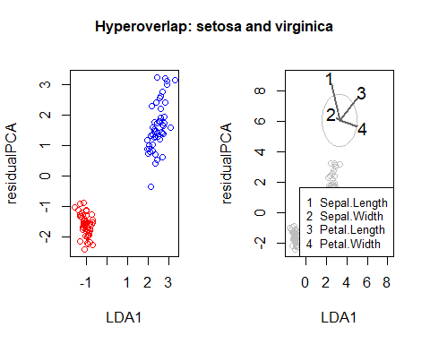

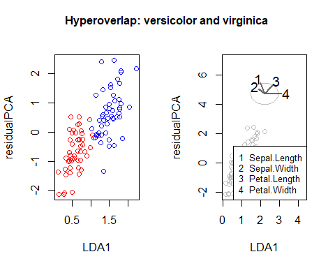

```r
transformed_data <- hyperoverlap_lda(setosa_virginica4d)  #plots the best two dimensions for visualising overlap
transformed_data <- hyperoverlap_lda(versicolor_virginica4d)
```

In three dimensions:

```r
close3d()  #close previous device
transformed_data <- hyperoverlap_lda(setosa_virginica4d, visualise3d=TRUE)
```

[interactive chart not shown]

```r
close3d()  #close previous device
transformed_data <- hyperoverlap_lda(versicolor_virginica4d, visualise3d=TRUE) #plots the best three dimensions for visualising overlap
```

[interactive chart not shown]

## Examining patterns of overlap in groups of entities

We might want to know which species overlap in certain variables from an entire genus. To do this, we can use `hyperoverlap_set` and visualise the results using `hyperoverlap_pairs_plot`

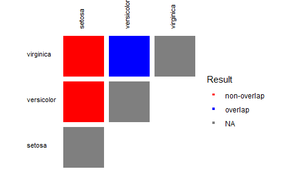

```r
all_spp <- hyperoverlap_set(test5[,1:4],test5$Species)
all_spp_plot <- hyperoverlap_pairs_plot(all_spp)
all_spp_plot
```